# Computer Science 1

[figure not shown]

New transform

6. Rename the transform to `Discretizing a CommuteTime`, and add description `Three levels`.

[figure not shown]

Add name and description

7. Clicking twice on ‘Add recode condition’ and typing the following text create this state. Select ‘Ordinal’ from the ‘Measure type’.

[figure not shown]

Clicking on ‘Add recode condition’

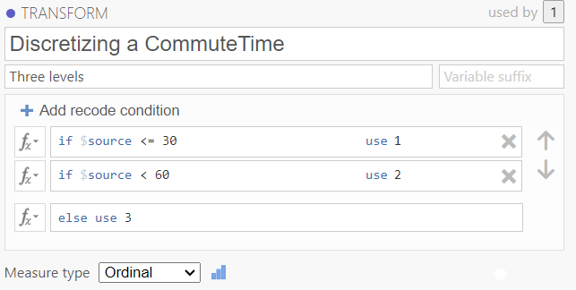

Recode conditions

8. Send the file `dataset_xlsx.omv` to the `abari.kurzus@gmail.com`. The subject of this email is `Lab07 - Problem 5`.

## Problem 6

> In this section, you will learn how to filter cases.

[*jamovi* comes the ability](https://blog.jamovi.org/2018/04/25/jamovi-filters.html) to filter out rows that you don’t want included in your analyses. There are a number of reasons why this might be appropriate. For example, you might want to only include people’s survey responses if they explicitly consented to having their data used, or you might want to exclude all left-handed people, or perhaps people who score ‘below chance’ in an experimental task. In some cases you just want to exclude extreme scores, for example those that score more than 3 standard deviations from the mean.

In our example, let’s select those male athletes whose height is greater than 190 cm.

1. Open `dataset_xlsx.omv` (see [Lab05 Problems](https://abarik.github.io/computer_science_1_2023_24_1/labs/CS_1_lab_05_jamovi_2.html)) in jamovi.
2. Select `Data / Filter` menu. Make the filter settings as shown in the pictures. As you can see, in the status bar, the number of filtered rows are 417.

[figure not shown]

Filter panel

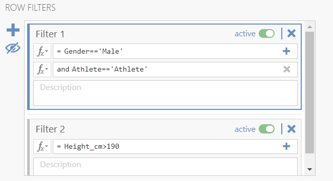

Filter conditions

3. Make the filters inactive without deleting them. As you can see, in the status bar, the number of filtered rows are 0.

[figure not shown]

Inactive filters

4. Send the file `dataset_xlsx.omv` to the `abari.kurzus@gmail.com`. The subject of this email is `Lab07 - Problem 6`.

## Problem 7

> In this section, you will learn how to evaluate a psychology test.

The `dataset_xlsx.omv` (see [Lab05 Problems](https://abarik.github.io/computer_science_1_2023_24_1/labs/CS_1_lab_05_jamovi_2.html)) has four test scores:

- `English` - Score on English placement test (out of 100 points) Numeric Scale
- `Reading` - Score on Reading placement test (out of 100 points) Numeric Scale
- `Math` - Score on Math placement test (out of 100 points) Numeric Scale
- `Writing` - Score on Writing placement test (out of 100 points)
1. Insert two new variables, `AverageScore` and `SumScore`, that will be calculated as the mean and sum of the four test scores. Use the `MEAN()` and `SUM()` functions in *jamovi*.
2. Send your `dataset_xlsx.omv` to the `abari.kurzus@gmail.com`. The subject of this email is `Lab 07 - Problem 7`.

**Scoring methods**

Whether to use the sum or average (mean) to evaluate a psychology test depends on the nature of the test, the specific research objectives, and the constructs being measured. Both methods have their advantages and can provide valuable insights, but they serve different purposes:

1. Sum (Total) Score:
   - Advantages: The total score provides a straightforward way to aggregate individual item or question responses. It represents the overall magnitude or intensity of the construct being measured. This is useful when you want to assess the cumulative effect of responses on a single construct.
   - Use Cases: Sum scores are commonly used in surveys or tests where responses are additive, such as in personality assessments, where multiple items contribute to a single trait score.
2. Average (Mean) Score:
   - Advantages: The mean score represents the central tendency of responses and is particularly useful when you want to gauge the typical or average level of a construct. It can be less sensitive to extreme values compared to sum scores.
   - Use Cases: Mean scores are often used when responses to individual items represent separate dimensions or facets of a construct, such as in multi-dimensional personality tests or questionnaires measuring diverse aspects of a behavior or trait.

In many cases, psychology tests and surveys use a combination of scoring methods. For instance, a test may provide both total and subscale scores to capture both the overall construct and its various dimensions. Researchers should carefully consider the characteristics of the test and the research context to determine which scoring method or combination of methods is most appropriate for their specific needs.

## Problem 8

> In this section, you will learn how to identify outliers.

The `dataset_xlsx.omv` has a variable `Height_cm` (see Problem 2). Insert 4 dichotomous variables (with values 0 and 1, where 1 means that the given observation in `Height_cm` is an outlier):

- `Height_cm_oZ2` - observations that are more than 2 standard deviations away from the mean would be marked with a 1.
- `Height_cm_oZ3` - observations that are more than 3 standard deviations away from the mean would be marked with a 1.
- `Height_cm_IQR1.5` - observations that fall below Q1 - 1.5 * IQR or above Q3 + 1.5 * IQR would be marked with a 1.
- `Height_cm_IQR2.5` - observations that fall below Q1 - 2.5 * IQR or above Q3 + 2.5 * IQR would be marked with a 1.
1. Insert two 4 new variables above.
2. Using a frequency table, show the distribution of the above four variables, that is, we need to know how many outliers there are in each case.
3. Create an html file `outliers.html` containing the images of the 4 frequency tables above, plus a short explanation for each of the 4 cases.
4. Send your `outliers.html` to the `abari.kurzus@gmail.com`. The subject of this email is `Lab 07 - Problem 8`.

**Outliers**

In statistics, an outlier is an observation or data point that significantly deviates from the rest of the data in a dataset. Outliers can be unusually high or low values and are sometimes referred to as “extreme values” or “anomalies.” These data points are often considered to be atypical or exceptional compared to the majority of the data.

Outliers can occur for various reasons, including measurement errors, data entry errors, natural variability, or genuine anomalies in the data. Identifying and handling outliers is an essential step in data analysis because they can have a substantial impact on statistical summaries and analysis results.

Here are a few methods for identifying outliers:

1. Visual Inspection: Plotting the data using graphs, such as histograms, box plots, or scatter plots, can help identify potential outliers. Points that are visibly distant from the bulk of the data may be outliers.
2. Z-Scores: Calculate the Z-score for each data point. Z-scores measure how many standard deviations a data point is from the mean. Data points with Z-scores significantly greater or smaller than a specified threshold (e.g., ±2 or ±3 standard deviations) are considered outliers.
3. Interquartile Range (IQR): The IQR is the range between the first quartile (Q1, 25th percentile) and the third quartile (Q3, 75th percentile) of the data. Data points that fall below Q1 - 1.5 * IQR or above Q3 + 1.5 * IQR are often considered outliers.
4. Expert Knowledge: In some cases, domain knowledge or subject-matter expertise is used to identify outliers, especially when unusual values have a logical explanation in the context of the data.